# HAR Weight Lifting

Frederic Bevia

28 juin 2016

### Executive Summary

In this project of prÃ©dictive machine learning, using R, we have tried to build a classifier for qualitative activity recognition of weight lifting exercises, based on the “Weight Lifting Exercises Dataset” from the Human Activity Recognition site . To do so, we have evaluated six classifications algorithms including Random Forest and Support Vector Machine, using K-fold crossvalidation and features selection. After having choose the model presenting the best accuracy, we have predicted with that model the outcome of the twenty tests cases in the test dataset, as required.

## The Problem

Today, using such new devices like smartphone and fitness bands, one thing that people regularly do is quantify how much of a particular activity they do, but they rarely quantify how well they do. On an expériment, described in the paper <ref http://groupware.les.inf.puc-rio.br/har#ixzz4CrzTgWBK>, six young health participants were asked to perform one set of 10 repetitions of the Unilateral Dumbbell Biceps Curl in five different fashions: - Class A: exactly according to the specification  
- Class B: throwing the elbows to the front - Class C: lifting the dumbbell only halfway  
- Class D: lowering the dumbbell only halfway - Class E: throwing the hips to the front

(This is the “classe” variable in the training set).

Various data were collected from accelerometers on the belt, forearm, arm, and dumbell of the 6 participants.

The goal here, is to predict the manner in which they did the exercise, using the classe variable as outcome in the training dataset.

Note: All the code is in the annex of these document

## Load and Prepare Data

Since the datasets are in the csv format, first of all, we open then in a spreadsheet (Excel or Calc) to have a peek on the datas. So we can note that there is a lot of missing datas, NA strings and even “#DIV/0!” strings. To correct that we will substitute all these strings by “NA” at the loading.

So after having loaded all the libraries required ..

we load the datasets:

```r
# Load and prep the datas
# change for the working directory
# setwd("/media/fred/Donnees/Donnees/Coursera/Machine Learning/devoir")

# load the dataset

PmlTrain <- read.csv("pml-training.csv", stringsAsFactors=FALSE, na.strings=c("NA","#DIV/0!",""))
PmlTest <- read.csv("pml-testing.csv", stringsAsFactors=FALSE,na.strings=c("NA","#DIV/0!",""))

# View(PmlTrain)
# summary(PmlTrain)
# head(PmlTrain)

#View(PmlTest )
#summary(PmlTest)
#head(PmlTest)
```

Dimensions of the training dataset:

```
## [1] 19622   160
```

Quite Big nNumber of samples : 19622 !

## Basic Exploratory Data Analysis

### Tidying Data

Before everything else, we have to to treat the NA case, because there is lot of columns full of NA.

*Frequency tables of the NAs :*

Table continues below

| 0 | 19216 | 19217 | 19218 | 19220 | 19221 | 19225 | 19226 | 19227 | 19248 |
| --- | --- | --- | --- | --- | --- | --- | --- | --- | --- |
| 60 | 67 | 1 | 1 | 1 | 4 | 1 | 4 | 2 | 2 |

| 19293 | 19294 | 19296 | 19299 | 19300 | 19301 | 19622 |
| --- | --- | --- | --- | --- | --- | --- |
| 1 | 1 | 2 | 1 | 4 | 2 | 6 |

Number of NA in the training dataset:

```
## [1] 1925102
```

Table continues below

| 0 | 19216 | 19217 | 19218 | 19220 | 19221 | 19225 | 19226 | 19227 | 19248 |
| --- | --- | --- | --- | --- | --- | --- | --- | --- | --- |
| 60 | 67 | 1 | 1 | 1 | 4 | 1 | 4 | 2 | 2 |

| 19293 | 19294 | 19296 | 19299 | 19300 | 19301 | 19622 |
| --- | --- | --- | --- | --- | --- | --- |
| 1 | 1 | 2 | 1 | 4 | 2 | 6 |

Number of NA in the testing dataset:

```
## [1] 2000
```

| 0 | 20 |
| --- | --- |
| 60 | 100 |

So we get rid of the attributes whose columns are full of NA

```r
PmlTrain<-PmlTrain[,colSums(is.na(PmlTrain)) < natrainmin]
PmlTest<-PmlTest[,colSums(is.na(PmlTest)) < natestmin]
```

We have now 60 variables for the training dataset, and 60 variables for the training dataset, But if we compare the attributes of the two sets, by intersecting and diff them, we can see that there is two differents attributes:

```
## [1] "classe"
```

```
## [1] "problem_id"
```

The two are in the last column. By the way , we can also see that the seven first attribute are unnecessary. so again, we get rid of them, and of course the last attribute of the testing set.

```r
PmlTrain<-PmlTrain[,8:60]


PmlTest<-PmlTest[,8:59]
```

Now the dimensions of the training set are: 19622, 53

### summary :

```
##    roll_belt        pitch_belt          yaw_belt       total_accel_belt
##  Min.   :-28.90   Min.   :-55.8000   Min.   :-180.00   Min.   : 0.00
##  1st Qu.:  1.10   1st Qu.:  1.7600   1st Qu.: -88.30   1st Qu.: 3.00
##  Median :113.00   Median :  5.2800   Median : -13.00   Median :17.00
##  Mean   : 64.41   Mean   :  0.3053   Mean   : -11.21   Mean   :11.31
##  3rd Qu.:123.00   3rd Qu.: 14.9000   3rd Qu.:  12.90   3rd Qu.:18.00
##  Max.   :162.00   Max.   : 60.3000   Max.   : 179.00   Max.   :29.00
##   gyros_belt_x        gyros_belt_y       gyros_belt_z
##  Min.   :-1.040000   Min.   :-0.64000   Min.   :-1.4600
##  1st Qu.:-0.030000   1st Qu.: 0.00000   1st Qu.:-0.2000
##  Median : 0.030000   Median : 0.02000   Median :-0.1000
##  Mean   :-0.005592   Mean   : 0.03959   Mean   :-0.1305
##  3rd Qu.: 0.110000   3rd Qu.: 0.11000   3rd Qu.:-0.0200
##  Max.   : 2.220000   Max.   : 0.64000   Max.   : 1.6200
##   accel_belt_x       accel_belt_y     accel_belt_z     magnet_belt_x
##  Min.   :-120.000   Min.   :-69.00   Min.   :-275.00   Min.   :-52.0
##  1st Qu.: -21.000   1st Qu.:  3.00   1st Qu.:-162.00   1st Qu.:  9.0
##  Median : -15.000   Median : 35.00   Median :-152.00   Median : 35.0
##  Mean   :  -5.595   Mean   : 30.15   Mean   : -72.59   Mean   : 55.6
##  3rd Qu.:  -5.000   3rd Qu.: 61.00   3rd Qu.:  27.00   3rd Qu.: 59.0
##  Max.   :  85.000   Max.   :164.00   Max.   : 105.00   Max.   :485.0
##  magnet_belt_y   magnet_belt_z       roll_arm         pitch_arm
##  Min.   :354.0   Min.   :-623.0   Min.   :-180.00   Min.   :-88.800
##  1st Qu.:581.0   1st Qu.:-375.0   1st Qu.: -31.77   1st Qu.:-25.900
##  Median :601.0   Median :-320.0   Median :   0.00   Median :  0.000
##  Mean   :593.7   Mean   :-345.5   Mean   :  17.83   Mean   : -4.612
##  3rd Qu.:610.0   3rd Qu.:-306.0   3rd Qu.:  77.30   3rd Qu.: 11.200
##  Max.   :673.0   Max.   : 293.0   Max.   : 180.00   Max.   : 88.500
##     yaw_arm          total_accel_arm  gyros_arm_x        gyros_arm_y
##  Min.   :-180.0000   Min.   : 1.00   Min.   :-6.37000   Min.   :-3.4400
##  1st Qu.: -43.1000   1st Qu.:17.00   1st Qu.:-1.33000   1st Qu.:-0.8000
##  Median :   0.0000   Median :27.00   Median : 0.08000   Median :-0.2400
##  Mean   :  -0.6188   Mean   :25.51   Mean   : 0.04277   Mean   :-0.2571
##  3rd Qu.:  45.8750   3rd Qu.:33.00   3rd Qu.: 1.57000   3rd Qu.: 0.1400
##  Max.   : 180.0000   Max.   :66.00   Max.   : 4.87000   Max.   : 2.8400
##   gyros_arm_z       accel_arm_x       accel_arm_y      accel_arm_z
##  Min.   :-2.3300   Min.   :-404.00   Min.   :-318.0   Min.   :-636.00
##  1st Qu.:-0.0700   1st Qu.:-242.00   1st Qu.: -54.0   1st Qu.:-143.00
##  Median : 0.2300   Median : -44.00   Median :  14.0   Median : -47.00
##  Mean   : 0.2695   Mean   : -60.24   Mean   :  32.6   Mean   : -71.25
```

[output cut: 50 more lines]

```
##  Max.   :311.00000   Max.   :231.0000   Max.   : 477.00   Max.   : 923.0
##  accel_forearm_z   magnet_forearm_x  magnet_forearm_y magnet_forearm_z
##  Min.   :-446.00   Min.   :-1280.0   Min.   :-896.0   Min.   :-973.0
##  1st Qu.:-182.00   1st Qu.: -616.0   1st Qu.:   2.0   1st Qu.: 191.0
##  Median : -39.00   Median : -378.0   Median : 591.0   Median : 511.0
##  Mean   : -55.29   Mean   : -312.6   Mean   : 380.1   Mean   : 393.6
##  3rd Qu.:  26.00   3rd Qu.:  -73.0   3rd Qu.: 737.0   3rd Qu.: 653.0
##  Max.   : 291.00   Max.   :  672.0   Max.   :1480.0   Max.   :1090.0
##  classe
##  A:5580
##  B:3797
##  C:3422
##  D:3216
##  E:3607
##
```

#### Frequencies of the classes

| A | B | C | D | E |
| --- | --- | --- | --- | --- |
| 5580 | 3797 | 3422 | 3216 | 3607 |

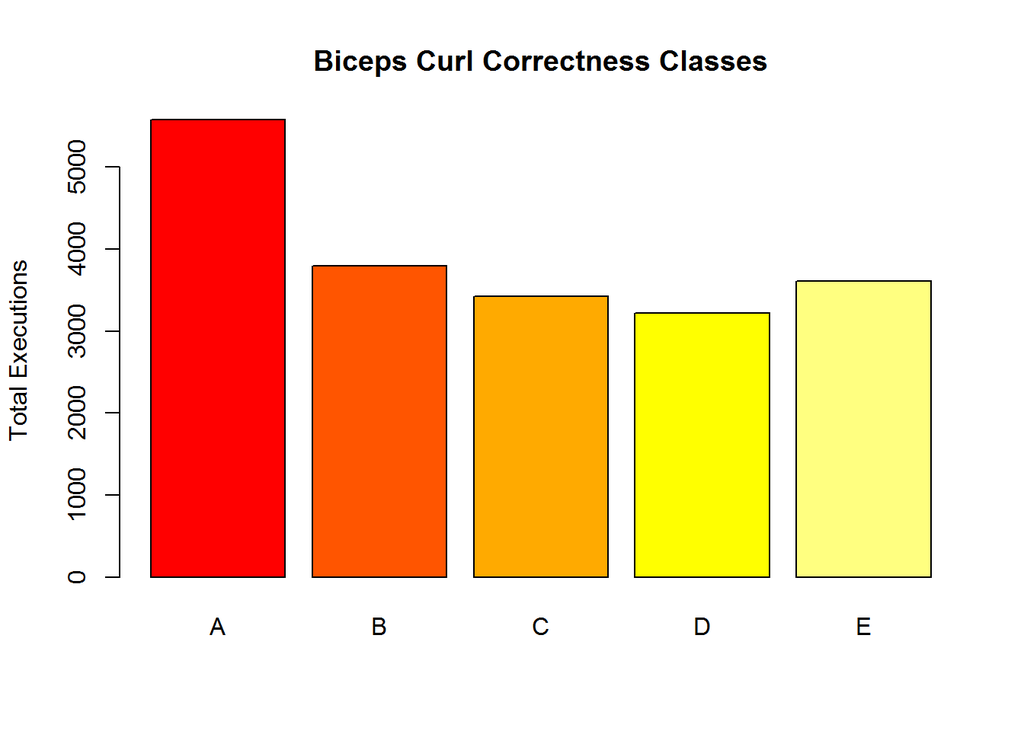

we can see that there is a relatively consistant distribution among the classes, except for the classe A whith a higher value, which mean that the partcipant did this move,the correct biceps curl, more than the others bad moves.

### features selection

In order to see if we can still lessen the number of sinificant variables lets do some feature selection, with the correlation matrix:

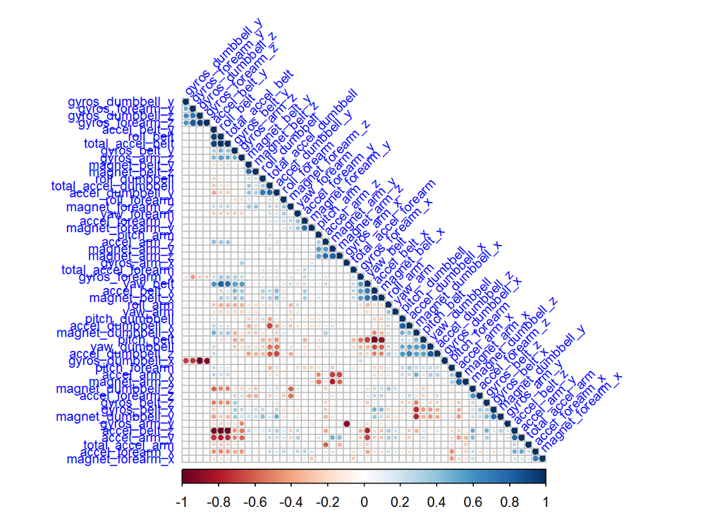

We can see that there is somes attributes wich are correlated. Let’s compute which of them are highly correlated (ideally >0.75):

```r
hCor <- findCorrelation(corMx, cutoff=0.75)



# print indexes of highly correlated attributes
print(hCor)
```

```
##  [1] 10  1  9 22  4 36  8  2 37 35 38 21 34 23 25 13 48 45 31 33 18
```

```r
PmlTrain<-PmlTrain[,-hCor]
PmlTest <-PmlTest[,-hCor]
```

Computing again the correlation matrix,

```
## [1] 19622    32
```

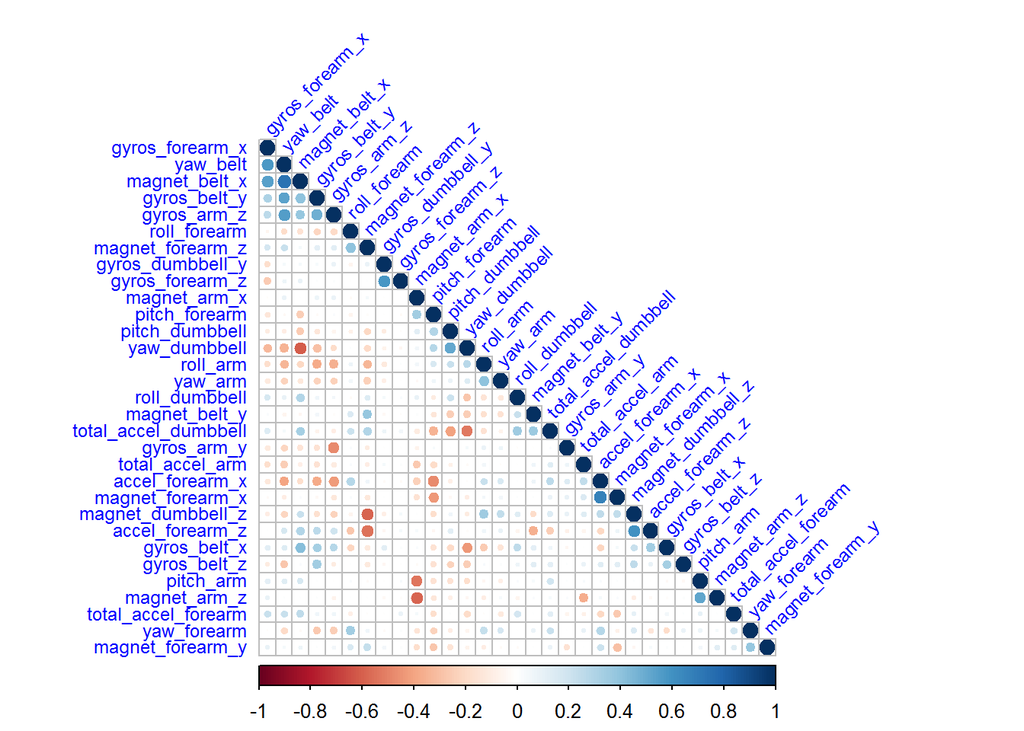

we can see now that there is less correlation among the 31 attributes remaning.

Now, we can evaluate somes algorithms and build models

## Building Models

Were going to create some models of the data and estimate their accuracy on unseen data.

To do so we’re going to

- Set-up the test to use 5-fold cross validation.
- Build 6 different models to predict Classes of Biceps movement
- Select the best model, upon is accuracy.

In order to test different type of algorithms, i choose six well know classifiers which are representatives of differents methods:

- CART: classification and regression tree
- LVQ: Learning Vector Quantization (a special case of neural network)
- LDA: Linear discriminant analysis
- GBM: Gradient Boosted Machine
- RF: Random Forest
- SVM: Support Vector Machine

For the cross-validation, each model is tuned and evaluated using 3 repeats of 5-fold, thanks to the caret package.

Note: Initialy, i would use 5 repeat and 10-fold, but on my laptop, for somes of the algorithms, it was not possible (infinite time or Rstudio out), even with the doParallel package which permit to use the for(4) cores of my PC.

```r
#  Use the cores Luke !!

registerDoParallel(cores=4)
```

To insure the accuracy the model which we will select, we are partionning the training test, and putting aside a part of the training dataset. We will use these test set to cross-validate the selected model before using it to predict the classes for the initial testing set.

```r
#set.seed(1960)
inTrain <- createDataPartition(PmlTrain$classe, p = 0.75,list=FALSE)
training <- PmlTrain[ inTrain,]
testing <- PmlTrain[-inTrain,]
```

## Predictives Algorithms Evalution

```r
# prepare training scheme
control <- trainControl(method="repeatedcv", number=5, repeats=3)



# train the CART model
set.seed(1960)
modelCart <- train(classe~., data=training , method="rpart", metric="Accuracy", trControl=control)

# train the LVQ model <- very long to execute on my PC
set.seed(1960)
modelLvq <- train(classe~., data=training , method="lvq",metric="Accuracy", trControl=control)

# train the LDA model
set.seed(1960)
modelLda <- train(classe~., data=training , method="lda",metric="Accuracy",trControl=control)

# train the GBM model
set.seed(1960)
modelGbm <- train(classe~., data=training , method="gbm",metric="Accuracy", trControl=control, verbose=FALSE)

# train the RF model
set.seed(1960)
modelRF<- train(classe~., data=training , method="rf",metric="Accuracy",trControl=control)

# train the SVM model
set.seed(1960)
modelSvm <- train(classe~., data=training , method="svmRadial",metric="Accuracy", trControl=control)
```

### Results

- **values**:

  Table continues below

  | CART~Accuracy | CART~Kappa | LVQ~Accuracy | LVQ~Kappa | LDA~Accuracy |
  | --- | --- | --- | --- | --- |
  | 0.5386 | 0.4202 | 0.4716 | 0.3354 | 0.5763 |
  | 0.5323 | 0.4125 | 0.5088 | 0.3747 | 0.5754 |
  | 0.5804 | 0.4715 | 0.4794 | 0.3415 | 0.5943 |
  | 0.5627 | 0.4486 | 0.4917 | 0.3556 | 0.5868 |
  | 0.5639 | 0.45 | 0.4704 | 0.3353 | 0.5805 |
  | 0.5406 | 0.4225 | 0.4815 | 0.3493 | 0.5732 |
  | 0.5567 | 0.4405 | 0.4613 | 0.316 | 0.5747 |
  | 0.5442 | 0.4267 | 0.4983 | 0.3638 | 0.5867 |
  | 0.564 | 0.4517 | 0.4791 | 0.343 | 0.5973 |
  | 0.5591 | 0.4437 | 0.4793 | 0.3456 | 0.5822 |
  | 0.5542 | 0.4425 | 0.4652 | 0.3301 | 0.5745 |
  | 0.5382 | 0.4188 | 0.4553 | 0.3101 | 0.5695 |
  | 0.569 | 0.4559 | 0.5071 | 0.3784 | 0.5815 |
  | 0.5674 | 0.4565 | 0.4781 | 0.3413 | 0.5804 |
  | 0.5391 | 0.4201 | 0.4861 | 0.3463 | 0.5751 |

  Table continues below

  | LDA~Kappa | GBM~Accuracy | GBM~Kappa | RF~Accuracy | RF~Kappa | SVM~Accuracy |
  | --- | --- | --- | --- | --- | --- |
  | 0.4634 | 0.947 | 0.9329 | 0.9908 | 0.9884 | 0.9069 |
  | 0.463 | 0.9378 | 0.9213 | 0.9905 | 0.988 | 0.8984 |
  | 0.4867 | 0.947 | 0.9329 | 0.9878 | 0.9845 | 0.9079 |
  | 0.4781 | 0.9521 | 0.9394 | 0.9864 | 0.9828 | 0.912 |
  | 0.4692 | 0.9436 | 0.9287 | 0.9922 | 0.9901 | 0.9083 |
  | 0.4603 | 0.9412 | 0.9256 | 0.9884 | 0.9854 | 0.9157 |
  | 0.4617 | 0.947 | 0.9329 | 0.9912 | 0.9888 | 0.9113 |
  | 0.4768 | 0.9477 | 0.9338 | 0.9884 | 0.9854 | 0.9201 |
  | 0.4903 | 0.948 | 0.9342 | 0.9915 | 0.9893 | 0.907 |
  | 0.4705 | 0.9429 | 0.9278 | 0.9918 | 0.9897 | 0.9147 |
  | 0.4616 | 0.9457 | 0.9313 | 0.9915 | 0.9893 | 0.9114 |
  | 0.4552 | 0.9399 | 0.9239 | 0.9912 | 0.9888 | 0.9103 |
  | 0.4701 | 0.9443 | 0.9295 | 0.9925 | 0.9905 | 0.9069 |
  | 0.4679 | 0.9514 | 0.9385 | 0.9905 | 0.988 | 0.9181 |
  | 0.4604 | 0.9412 | 0.9256 | 0.9888 | 0.9858 | 0.9049 |

  | SVM~Kappa |
  | --- |
  | 0.8819 |
  | 0.8712 |
  | 0.8832 |
  | 0.8885 |
  | 0.8838 |
  | 0.8932 |
  | 0.8876 |
  | 0.8987 |
  | 0.8821 |
  | 0.8919 |
  | 0.8876 |
  | 0.8863 |
  | 0.8821 |
  | 0.8962 |
  | 0.8794 |

- **call**: `summary.resamples(object = results)`
- **statistics**:
  - **Accuracy**:

    |  | Min. | 1st Qu. | Median | Mean | 3rd Qu. | Max. | NA’s |
    | --- | --- | --- | --- | --- | --- | --- | --- |
    | **CART** | 0.5323 | 0.5398 | 0.5567 | 0.554 | 0.5639 | 0.5804 | 0 |
    | **LVQ** | 0.4553 | 0.471 | 0.4793 | 0.4809 | 0.4889 | 0.5088 | 0 |
    | **LDA** | 0.5695 | 0.5749 | 0.5804 | 0.5806 | 0.5844 | 0.5973 | 0 |
    | **GBM** | 0.9378 | 0.9421 | 0.9457 | 0.9451 | 0.9473 | 0.9521 | 0 |
    | **RF** | 0.9864 | 0.9886 | 0.9908 | 0.9902 | 0.9915 | 0.9925 | 0 |
    | **SVM** | 0.8984 | 0.9069 | 0.9103 | 0.9103 | 0.9134 | 0.9201 | 0 |

  - **Kappa**:

    |  | Min. | 1st Qu. | Median | Mean | 3rd Qu. | Max. | NA’s |
    | --- | --- | --- | --- | --- | --- | --- | --- |
    | **CART** | 0.4125 | 0.4214 | 0.4425 | 0.4388 | 0.4508 | 0.4715 | 0 |
    | **LVQ** | 0.3101 | 0.3353 | 0.343 | 0.3444 | 0.3525 | 0.3784 | 0 |
    | **LDA** | 0.4552 | 0.4616 | 0.4679 | 0.469 | 0.4737 | 0.4903 | 0 |
    | **GBM** | 0.9213 | 0.9267 | 0.9313 | 0.9306 | 0.9334 | 0.9394 | 0 |
    | **RF** | 0.9828 | 0.9856 | 0.9884 | 0.9877 | 0.9893 | 0.9905 | 0 |
    | **SVM** | 0.8712 | 0.8821 | 0.8863 | 0.8863 | 0.8902 | 0.8987 | 0 |

- **models**: *CART*, *LVQ*, *LDA*, *GBM*, *RF* and *SVM*
- **metrics**: *Accuracy* and *Kappa*
- **methods**:

  | CART | LVQ | LDA | GBM | RF | SVM |
  | --- | --- | --- | --- | --- | --- |
  | rpart | lvq | lda | gbm | rf | svmRadial |

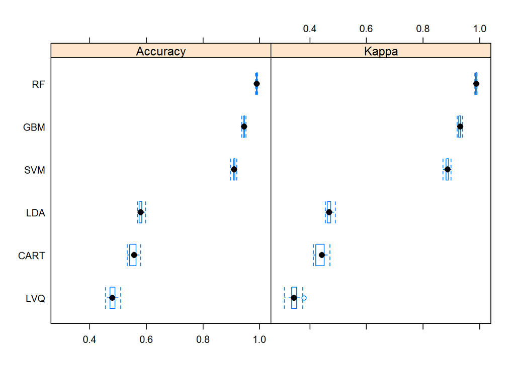

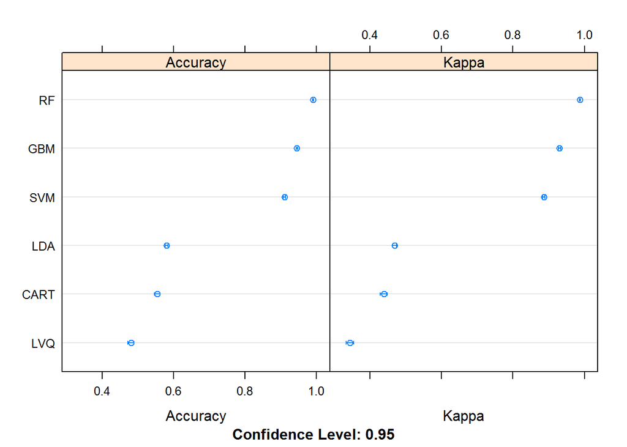

Both for the accuracy (o.99) and the Kappa (near 1), the model which is the best is the one produced by the **Random Forrest** Algorithm. As we can see all the more on the boxplot and the dotplot. We can also see that the tree first algorithms, cART, LVQ and LDA are not performing very well, while GBM and SVM are near the performances of the RF.

So we select these model to do the predictions .

#### Importance

Before doing so, we can look at the importance of the variables:

- **importance**:

  |  | Overall |
  | --- | --- |
  | **yaw_belt** | 799.1 |
  | **gyros_belt_x** | 250.3 |
  | **gyros_belt_y** | 249.6 |
  | **gyros_belt_z** | 441.4 |
  | **magnet_belt_x** | 357.1 |
  | **magnet_belt_y** | 575.3 |
  | **roll_arm** | 418.9 |
  | **pitch_arm** | 289.7 |
  | **yaw_arm** | 345.6 |
  | **total_accel_arm** | 230.9 |
  | **gyros_arm_y** | 270.9 |
  | **gyros_arm_z** | 165.4 |
  | **magnet_arm_x** | 355.6 |
  | **magnet_arm_z** | 301.9 |
  | **roll_dumbbell** | 517.2 |
  | **pitch_dumbbell** | 378.5 |
  | **yaw_dumbbell** | 414.5 |
  | **total_accel_dumbbell** | 416.7 |
  | **gyros_dumbbell_y** | 401.4 |
  | **magnet_dumbbell_z** | 668.7 |
  | **roll_forearm** | 521.3 |
  | **pitch_forearm** | 609.1 |
  | **yaw_forearm** | 281.9 |
  | **total_accel_forearm** | 223 |
  | **gyros_forearm_x** | 188.6 |
  | **gyros_forearm_z** | 193 |
  | **accel_forearm_x** | 395.8 |
  | **accel_forearm_z** | 328.1 |
  | **magnet_forearm_x** | 319.9 |
  | **magnet_forearm_y** | 341.5 |
  | **magnet_forearm_z** | 351.6 |

- **model**: rf
- **calledFrom**: varImp

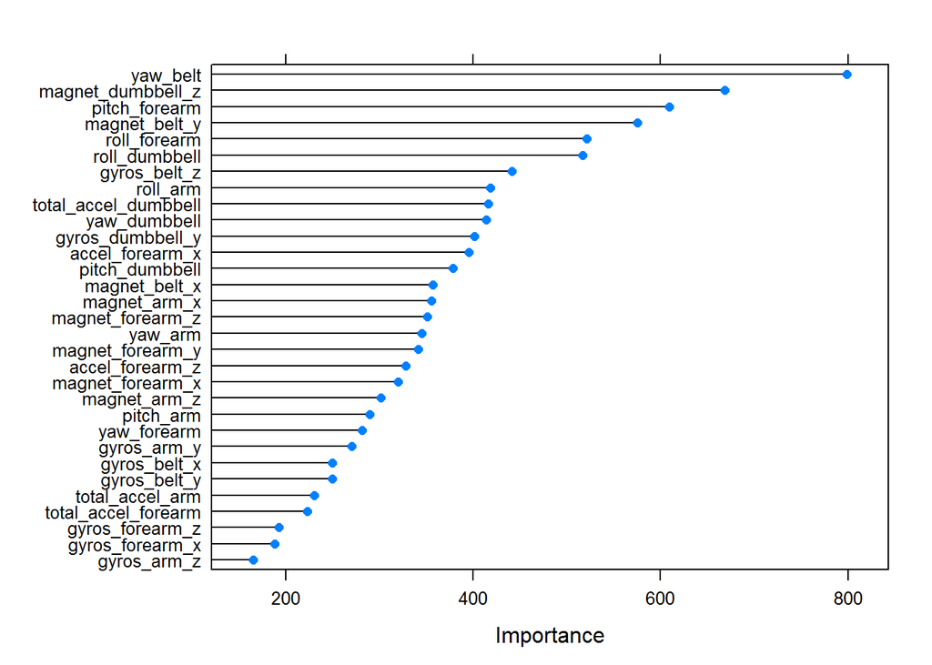

We can see here that we could have eliminated again some variables, the 3 or 4 last one.

## Cross Validation againts the validation set

Now, before applying the model to the real test set, we are testing it again the part of the training set that we have pu apart for that:

```r
prediction <- predict(modelRF, testing)
confMX<-confusionMatrix(testing$classe, prediction)

print(confMX)
```

```
## Confusion Matrix and Statistics
##
##           Reference
## Prediction    A    B    C    D    E
##          A 1395    0    0    0    0
##          B    5  939    5    0    0
##          C    0    6  846    3    0
##          D    0    0   19  784    1
##          E    0    0    0    3  898
##
## Overall Statistics
##
##                Accuracy : 0.9914
##                  95% CI : (0.9884, 0.9938)
##     No Information Rate : 0.2855
##     P-Value [Acc > NIR] : < 2.2e-16
##
##                   Kappa : 0.9892
##  Mcnemar's Test P-Value : NA
##
## Statistics by Class:
##
##                      Class: A Class: B Class: C Class: D Class: E
## Sensitivity            0.9964   0.9937   0.9724   0.9924   0.9989
## Specificity            1.0000   0.9975   0.9978   0.9951   0.9993
## Pos Pred Value         1.0000   0.9895   0.9895   0.9751   0.9967
## Neg Pred Value         0.9986   0.9985   0.9941   0.9985   0.9998
## Prevalence             0.2855   0.1927   0.1774   0.1611   0.1833
## Detection Rate         0.2845   0.1915   0.1725   0.1599   0.1831
## Detection Prevalence   0.2845   0.1935   0.1743   0.1639   0.1837
## Balanced Accuracy      0.9982   0.9956   0.9851   0.9938   0.9991
```

```r
pander(postResample(prediction, testing$classe))
```

| Accuracy | Kappa |
| --- | --- |
| 0.9914 | 0.9892 |

## Testing the Model

We’re applying the model to the initial test Dataset, to predict the classes of the 20 samples

```r
#
predictedClasses <- predict(modelRF, PmlTest)

print(predictedClasses)
```

```
##  [1] B A B A A E D B A A B C B A E E A B B B
## Levels: A B C D E
```

## Conclusions

In these project we have evaluated several algorith to produce a model with good accuracy, and even if it’s the Random Forest which is the better, two others algorithms are very near in term of accuracy, the GBM and a SVM. But to be complete, we should take into account the fact that the most perfoming algorithms are very greedy in cpu and RAM, and most consuming in time, and because of that I couldn’t do more than 3 repeats on 5 fold in the repeated cross-validation K-fold method.Also, we might improve the features selection.

## Annex

### References

Velloso, E.; Bulling, A.; Gellersen, H.; Ugulino, W.; Fuks, H. Qualitative Activity Recognition of Weight Lifting Exercises. Proceedings of 4th International Conference in Cooperation with SIGCHI (Augmented Human ’13) . Stuttgart, Germany: ACM SIGCHI, 2013.

http://www.academia.edu/7619059/Human_Activity_Recognition_using_machine_learning http://link.springer.com/article/10.1007%2Fs12652-011-0068-9#page-1

http://michaelryoo.com/cvpr2011tutorial/

http://blog.aicry.com/r-parallel-computing-in-5-minutes/

https://en.wikipedia.org/wiki/Decision_tree_learning https://en.wikipedia.org/wiki/Learning_vector_quantization https://en.wikipedia.org/wiki/Gradient_boosting https://en.wikipedia.org/wiki/Support_vector_machine https://en.wikipedia.org/wiki/Linear_discriminant_analysis

#### Code

```r
# load the libraries
library(mlbench)
library(caret)
library(corrplot)
library(rpart)
library(class)
library(randomForest)
library(MASS)
library(gbm)
library(survival)
library(splines)
library(parallel)
library(plyr)
library(doParallel)
library(kernlab)

# Load and prep the datas
# change for the working directory
# setwd("/media/fred/Donnees/Donnees/Coursera/Machine Learning/devoir")

# load the dataset

PmlTrain <- read.csv("pml-training.csv", stringsAsFactors=FALSE, na.strings=c("NA","#DIV/0!",""))
PmlTest <- read.csv("pml-testing.csv", stringsAsFactors=FALSE,na.strings=c("NA","#DIV/0!",""))

# View(PmlTrain)
# summary(PmlTrain)
# head(PmlTrain)

#View(PmlTest )
#summary(PmlTest)
#head(PmlTest)

dim(PmlTrain)
dim(PmlTest)

# The outcome as factor
PmlTrain$classe <-as.factor(PmlTrain$classe)


# Tidying Data
# The Na case

nbnatraining <-sum(is.na(PmlTrain)) #very important Na
nbnatesting <- sum(is.na(PmlTest))

tna.testing<-table(colSums(is.na(PmlTest)))
tna.training<-table(colSums(is.na(PmlTrain)))

natrainmin<-as.numeric(min(names(tna.training)[-1]))
natestmin<-as.numeric(min(names(tna.testing)[-1]))


PmlTrain<-PmlTrain[,colSums(is.na(PmlTrain)) < natrainmin]
PmlTest<-PmlTest[,colSums(is.na(PmlTest)) < natestmin]

length(names(PmlTrain))
length(names(PmlTest))
length(intersect(names(PmlTrain),names(PmlTest)))
setdiff(names(PmlTrain),names(PmlTest))
setdiff(names(PmlTest),names(PmlTrain))

PmlTrain<-PmlTrain[,8:60]
dim(PmlTrain)

PmlTest<-PmlTest[,8:59]

print(dim(PmlTrain))

print(summary(PmlTrain))


freqclasse<-table(PmlTrain$classe)
barplot(freqclasse, main="Biceps Curl Correctness Classes", ylab= "Total Executions",beside=TRUE, col=heat.colors(5))


#features selection

set.seed(1960)
# calculate correlation matrix
corMx<- cor(PmlTrain[,-53])
# summarize the correlation matrix
#print(corMx)
corrplot(corMx, method = "circle", type="lower", order="hclust", tl.cex = 0.75, tl.col="blue", tl.srt = 45, addrect = 3)
# find attributes that are highly corrected (ideally >0.75)
hCor <- findCorrelation(corMx, cutoff=0.75)
# print indexes of highly correlated attributes
print(hCor)

PmlTrain<-PmlTrain[,-hCor]
PmlTest <-PmlTest[,-hCor]

print(dim(PmlTrain))

corMx2<- cor(PmlTrain[,-32])
corrplot(corMx2, method = "circle", type="lower", order="hclust", tl.cex = 0.75, tl.col="blue", tl.srt = 45, addrect = 3)

#  Use the cores Luke !!

registerDoParallel(cores=4)


set.seed(1960)

# Partition in a training and an intermediary test set, the latter will serve to cross-validate the selected model
# before applying it to the test dataset

inTrain <- createDataPartition(PmlTrain$classe, p = 0.75,list=FALSE)
training <- PmlTrain[ inTrain,]
testing <- PmlTrain[-inTrain,]


# prepare training scheme
control <- trainControl(method="repeatedcv", number=5, repeats=3)



# train the CART model
set.seed(1960)
modelCart <- train(classe~., data=training , method="rpart", metric="Accuracy", trControl=control)

# train the LVQ model <- very long to execute on my PC
set.seed(1960)
modelLvq <- train(classe~., data=training , method="lvq",metric="Accuracy", trControl=control)

# train the LDA model
set.seed(1960)
modelLda <- train(classe~., data=training , method="lda",metric="Accuracy",trControl=control)

# train the GBM model
set.seed(1960)
modelGbm <- train(classe~., data=training , method="gbm",metric="Accuracy", trControl=control, verbose=FALSE)

# train the RF model
set.seed(1960)
modelRF<- train(classe~., data=training , method="rf",metric="Accuracy",trControl=control)

# train the SVM model
set.seed(1960)
modelSvm <- train(classe~., data=training , method="svmRadial",metric="Accuracy", trControl=control)

# collect resamples
results <- resamples(list( CART=modelCart,LVQ=modelLvq, LDA=modelLda, GBM=modelGbm, RF=modelRF, SVM=modelSvm))
# summarize the distributions

print(summary(results))

# boxplots of results
bwplot(results)
# dot plots of results
dotplot(results)


# estimate variable importance
importance <- varImp(modelRF, scale=FALSE)

# summarize importance
print(importance)

# plot importance

plot(importance)

#Cross Validation againts the  validation set

prediction <- predict(modelRF, testing)
confMX<-confusionMatrix(testing$classe, prediction)

accuracy<-postResample(prediction, testing$classe)

print(accuracy)

# Applying the model to the initial test Dataset
# to predict the classes of the 20 samples

predictedClasses <- predict(modelRF, PmlTest)
print(predictedClasses)
```